# BF HW-5

## lets try a different way to decompose

```r
decomp_usmelec <- decompose(usmelec)

attributes(decomp_usmelec)
```

```
## $names
## [1] "x"        "seasonal" "trend"    "random"   "figure"   "type"
##
## $class
## [1] "decomposed.ts"
```

```r
seasadj(decomp_usmelec)
```

```
##           Jan      Feb      Mar      Apr      May      Jun      Jul      Aug
## 1973 147.4035 162.1730 159.8441 168.1987 158.0497 148.7131 133.2621 137.7599
## 1974 144.7405 161.3820 162.0281 170.9217 164.4677 143.9091 137.7761 134.5139
## 1975 151.8085 165.9830 167.4461 175.1047 164.1857 150.1861 136.5861 140.3259
## 1976 165.7945 175.6000 176.1531 182.0767 168.3187 161.1431 146.2201 147.0339
## 1977 183.8505 181.5830 181.1231 185.7267 180.2507 168.5001 158.6971 156.7579
## 1978 185.2935 192.3800 185.1471 188.6227 186.2037 176.0541 162.4761 167.0539
## 1979 197.1725 205.2210 194.8401 198.8697 189.0637 174.4451 162.0511 165.4959
## 1980 187.4815 207.5950 199.4311 197.6267 186.7207 177.2171 176.5871 176.0239
## 1981 193.9435 198.4940 197.5201 201.4507 188.7937 190.4901 180.1841 171.0339
## 1982 196.8795 199.1800 199.6541 201.4867 188.1347 173.9161 170.3941 166.2869
## 1983 183.0565 191.3590 194.4551 199.2787 185.3797 178.8361 179.9761 190.5879
## 1984 204.1095 208.4440 212.0731 209.9907 203.2047 197.4361 181.0551 189.9269
## 1985 215.3335 217.1220 206.9361 213.7827 207.7777 193.1511 186.5331 186.6809
## 1986 204.9465 211.2160 208.8011 214.9797 208.3017 202.8031 202.4831 185.7969
```

[output cut: 69 more lines]

- decompose() function is another way we can use to decompose our data.
- In the attribute we can see that there are trend, seasonal, and random variables.
- seasadj also is useful to adjust the seasonal variation as the decompose() function.

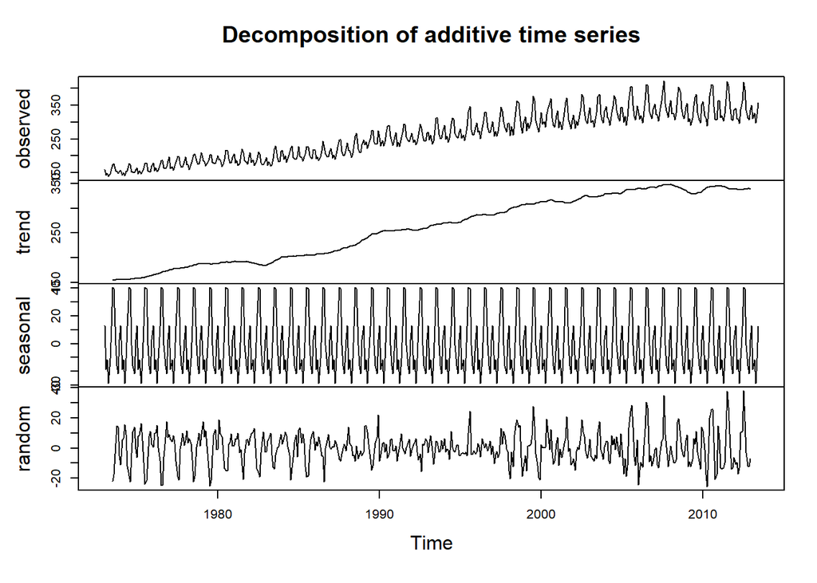

```r
plot(decomp_usmelec)
```

- The order of trend, seasonal, and irregularity changes while the visual remains the same.
- “random” is used to show the irregularity component and it is shown in the form of a line graph.